# Analysis

Our primary tool for analysing the data is BERTopic, a topic modelling technique which allows us to gain insight on the most common topic for each subreddit and the words associated with each topic.

### Separate Analysis of Each State

Below, we have included graphs and figures from our separate analysis of four states. Arkansas, Texas, Indiana, and Florida provide a diversity of sociopolitical landscapes, making them ideal for investigation. Arkansas, with its deeply conservative and rural focus, contrasts sharply with the increasingly progressive urban centers within Texas, which also balances a strong conservative presence in its rural regions. Indiana, traditionally conservative with strong rural values, provides a different Midwestern perspective. Florida, as a battleground state, showcases a unique blend of influences from its diverse demographics, significant retiree population, and a mix of liberal and conservative areas. This variety allows for a comprehensive analysis of sociopolitical dynamics across different environments.

**Arkansas**

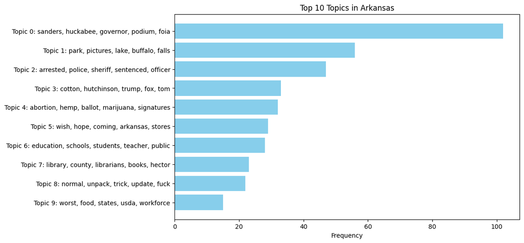

Source: data for every state #

[interactive chart not shown]

Arkansas’ top topic is seemingly politics related, including the name Huckabee, the former governor, and Sanders, the current governor. Other high ranking topics include one denoting Arkansas’ rich natural landscapes and outdoor recreational opportunities (topic 1), with mentions of “park,” “lake,” “buffalo,” and “falls,” highlighting popular destinations for hiking, boating, and scenic views, such as the Buffalo National River and its waterfalls. In topic 9, the terms “worst,” “food,” “states,” “USDA,” and “workforce” suggest a discussion related to various aspects of state conditions, such as economic indicators, agricultural policies, and labor force statistics. These topics could potentially reflect concerns about state rankings, food insecurity, government programs like the USDA, and workforce development initiatives.

**Texas**

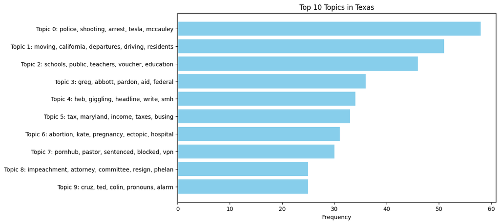

[interactive chart not shown]

In Texas, topic 3 - “Greg Abbott,” “pardon,” “aid,” and “federal” - suggests discussions related to Governor Greg Abbott’s actions or policies, including potential pardons, federal assistance programs, and interactions between the state and federal government. Topic 9, including “Cruz,” “Ted,” “Colin,” “pronouns,” and “alarm”, may indicate discussions related to Senator Ted Cruz, potentially including his statements or actions, along with broader political debates involving gender pronouns and alarmist rhetoric.

**Florida**

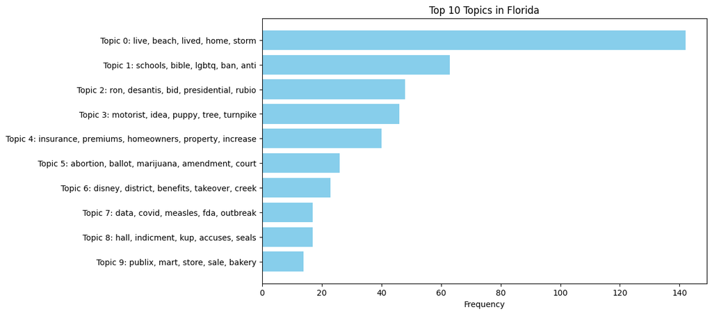

[interactive chart not shown]

In Florida, topics such as “schools,” “bible,” “anti,” “LGBTQ,” and “ban” could imply discussions related to education policies, religious influences in public institutions, opposition to certain social movements, LGBTQ+ rights, and potentially discussions about banning certain activities or behaviors within the state. Topic 2 suggests discussions in Florida surrounding figures like Governor Ron DeSantis, potential bids for presidential candidacy, and political figures like Marco Rubio. Topic 7, referencing “data,” “COVID,” “measles,” “FDA,” and “outbreak”, could suggest discussions in Florida related to data analysis, COVID-19 pandemic updates, potential outbreaks of diseases like measles, regulations by the Food and Drug Administration (FDA), and public health concerns.

**Indiana**

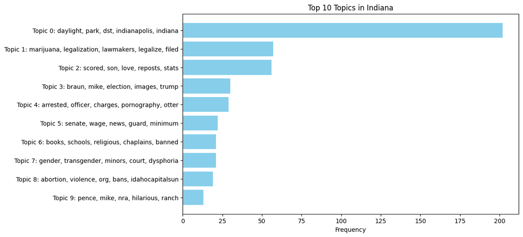

[interactive chart not shown]

### Cross Analysis Between States

We also did a cross analysis between the two states to identify the degree of similarity of the topics discussed in their respective reddits based on their cosine similarity.

**Texas & Arkansas**

[interactive chart not shown]

**Florida & Indiana**

[interactive chart not shown]